# Analisi Schede di Dimissioni Ospedaliere

| Marco Gaudio |

22 marzo, 2021

The aim of this document is to analyze the data related to the italian *Schede di Dimissioni Ospedaliere* (SDO), in the period 2016 - 2019. The data are provided by the [**Italian Ministry of Health**](http://www.salute.gov.it/portale/temi/p2_6.jsp?lingua=italiano&id=1237&area=ricoveriOspedalieri&menu=vuotolink).

The document is composed by 4 sections:

- **section 1** provides an analysis for each of the 5 activities (*Acuti Regime ordinario*; *Acuti Regime diurno*, *Riabilitazione Regime ordinario*; *Riabilitazione Regime diurno*; *Lungodegenza*) and considering the differences in the period studied.
- **section 2** analyses the hospitalization rates, first providing an overview for Italy as a whole, and then analysing the rates for each of the 5 activities in in the period 2016-2019, considering different regions, gender and age categories.
- **section 3** gives an overview of the Italian and English population in 2019, then an analysis of England’s total number of surgeries (that can be compared to the total number of the italian **“dimissioni”**) and surgical incidences (the italian **“tasso di ospedalizzazione”**) is made. Lastly, it shows a comparison between the overall hospitalization rates in Italy and England, thanks to the data provided by the [**Health and Social Care Information Centre**](https://digital.nhs.uk/), now called NHS Digital.
- **section 4** proposes an analysis of the data about hospitalization discharges collected from two different sources: [**Istat**](http://dati.istat.it/) and Italian Ministry of Health.

### An overview of hospitalization discharges in Italy

The following graph shows the total number of hospital discharges divided by activity for the 4 years of analysis.

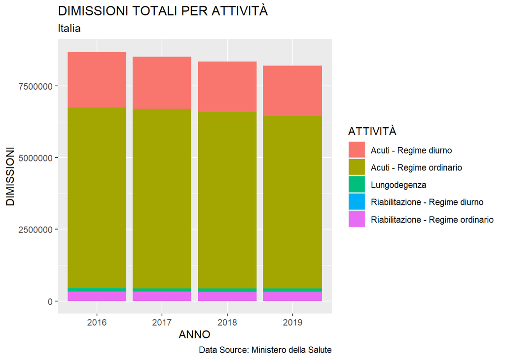

Table 1.1.1 shows the total number of discharges for all the activities and its percentage variation through the period of analysis. As shown here, the total number of hospital discharges is decreased from 2016 to 2019. In particular, from 2018 to 2019 the number has dropped from 8.356.874 to 8.212.031, with a decrease of 1.733%.

|  | ANNO | DIMISSIONI | VARIAZIONE % |
| --- | --- | --- | --- |
| 1 | 2016 | 8696486 |  |
| 2 | 2017 | 8522456 | -2.001 |
| 3 | 2018 | 8356874 | -1.943 |
| 4 | 2019 | 8212031 | -1.733 |

# 1 ATTIVITÀ

## 1.1 Acuti - Regime ordinario.

the following section is aimed to analyze the discharge in *Acuti - Regime ordinario*, from 2016 to 2019 in Italy.

### 1.1.1 DIMISSIONI

Table 1.1.2 provides a summary of the hospedalization discharges in *“Acuti - Regime ordinario”* and the percentage variation year by year.

|  | ANNO | DIMISSIONI | VARIAZIONE % |
| --- | --- | --- | --- |
| 1 | 2016 | 6288571 |  |
| 2 | 2017 | 6256025 | -0.518 |
| 3 | 2018 | 6151722 | -1.667 |
| 4 | 2019 | 6020466 | -2.134 |

This bar chart shows the hospital discharges by MDC for each year of the analysis.

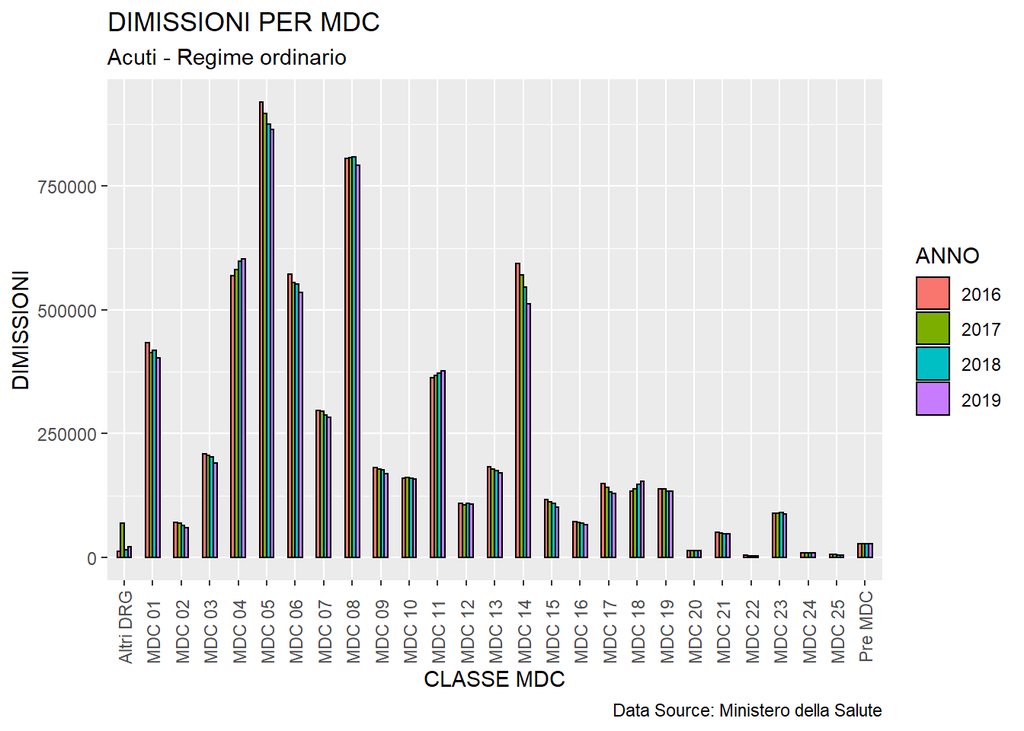

As shown from the bar chart, over the 4 years of analysis, the MDC class with the greatest number of discharges for the activity *Acuti - Regime ordinario* is the **MDC 05 - Malattie e disturbi dell’apparato cardiocircolatorio**, followed by **MDC 08 - Malattie e disturbi del sistema muscolo-scheletrico e del tessuto connettivo** and **MDC 04 - Malattie e disturbi dell’apparato respiratorio**.

The following table provides a summary of the discharges for each MDC class and for each year.

|  | CLASSE_MDC | DIMISSIONI | ANNO |
| --- | --- | --- | --- |
| 1 | 01 - Malattie e disturbi del sistema nervoso | 432980 | 2016 |
| 2 | 02 - Malattie e disturbi dell'occhio | 71046 | 2016 |
| 3 | 03 - Malattie e disturbi dell'orecchio, del naso, della bocca e della gola | 208407 | 2016 |
| 4 | 04 - Malattie e disturbi dell'apparato respiratorio | 568882 | 2016 |
| 5 | 05 - Malattie e disturbi dell'apparato cardiocircolatorio | 919182 | 2016 |
| 6 | 06 - Malattie e disturbi dell'apparato digerente | 572032 | 2016 |
| 7 | 07 - Malattie e disturbi epatobiliari e del pancreas | 297023 | 2016 |
| 8 | 08 - Malattie e disturbi del sistema muscolo-scheletrico e del tessuto connettivo | 806091 | 2016 |
| 9 | 09 - Malattie e disturbi della pelle, del tessuto sottocutaneo e della mammella | 181450 | 2016 |
| 10 | 10 - Malattie e disturbi endocrini, nutrizionali e metabolici | 160499 | 2016 |

[output cut: 98 more lines]

### 1.1.2 PERCENTUALE GIORNI DIMISSIONI PER MDC.

The following pie charts show the number of days before discharge in percentage for the 4 years analysed. As shown, the highest percentage of discharges for the activity *Acuti - Regime ordinario* is *DIMISSIONI TRA 4 GIORNI E VALORE SOGLIA*, with 55.6%. This means that 55.6% of the hospitalization discharges in this activity lasts between 4 days and the treshold value (**Valore Soglia**).

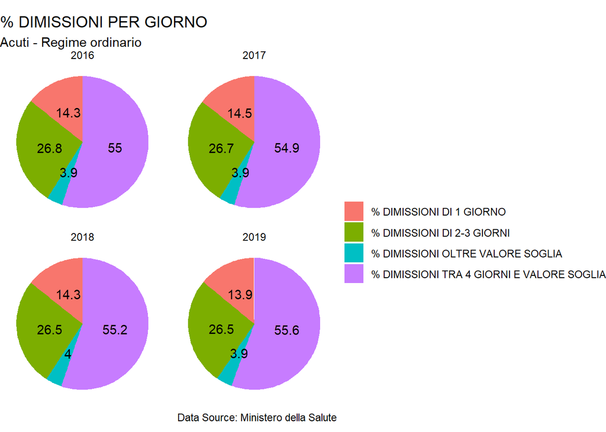

The bar chart below shows the distribution of discharges in *Acuti - Regime ordinario* per age category, for each year of analysis.

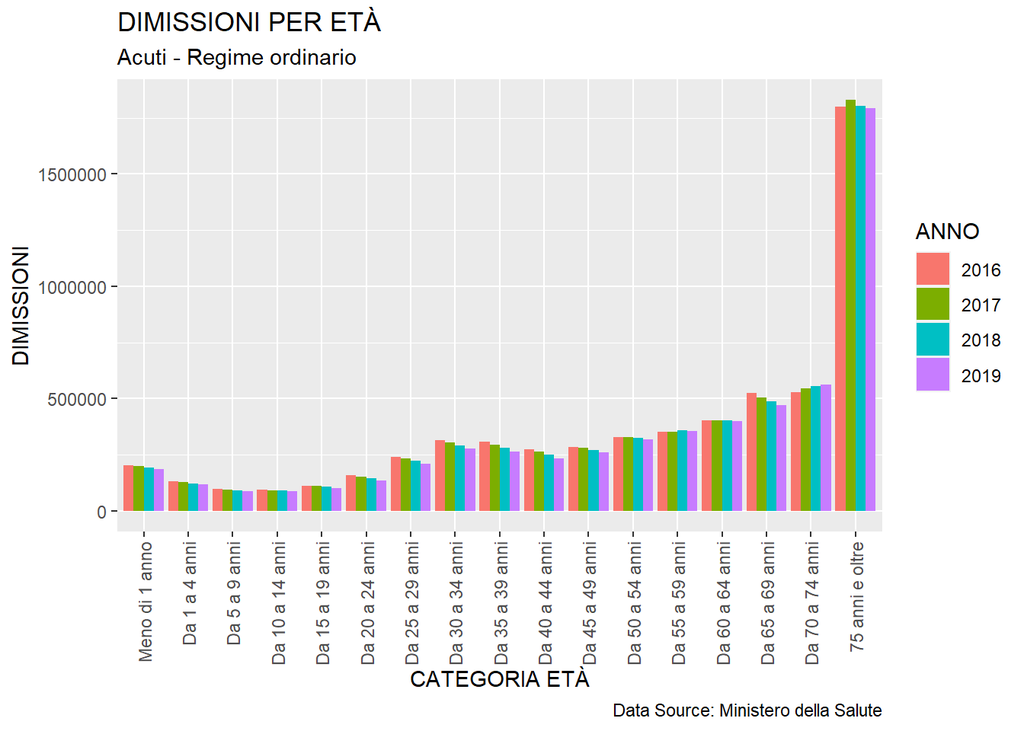

The following table provides a summary of the data presented about hospitalization discharges by age category.

|  | Categoria età | MASCHI | FEMMINE | ANNO | ATTIVITÀ |
| --- | --- | --- | --- | --- | --- |
| 1 | Meno di 1 anno | 111589 | 90134 | 2016 | Acuti - Regime ordinario |
| 2 | Da 1 a 4 anni | 76059 | 55637 | 2016 | Acuti - Regime ordinario |
| 3 | Da 5 a 9 anni | 56504 | 40529 | 2016 | Acuti - Regime ordinario |
| 4 | Da 10 a 14 anni | 53620 | 40336 | 2016 | Acuti - Regime ordinario |
| 5 | Da 15 a 19 anni | 57735 | 55093 | 2016 | Acuti - Regime ordinario |
| 6 | Da 20 a 24 anni | 57990 | 99408 | 2016 | Acuti - Regime ordinario |
| 7 | Da 25 a 29 anni | 58913 | 181716 | 2016 | Acuti - Regime ordinario |
| 8 | Da 30 a 34 anni | 62343 | 253989 | 2016 | Acuti - Regime ordinario |
| 9 | Da 35 a 39 anni | 78297 | 229222 | 2016 | Acuti - Regime ordinario |
| 10 | Da 40 a 44 anni | 107785 | 166628 | 2016 | Acuti - Regime ordinario |

[output cut: 58 more lines]

### 1.1.3 GIORNATE DI DEGENZA

The following graph shows the *“Giorni di Degenza”* for each MDC and over the years of analysis.

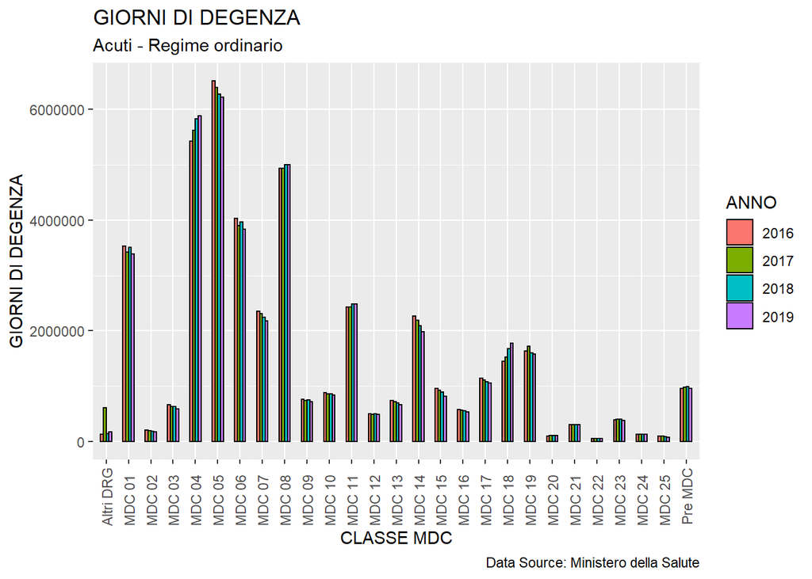

Table 1.1.5 provides a summary for *Giorni di Degenza* by MDC for each year.

|  | CLASSE_MDC | GIORNATE DI DEGENZA | ANNO |
| --- | --- | --- | --- |
| 1 | 01 - Malattie e disturbi del sistema nervoso | 3524885 | 2016 |
| 2 | 02 - Malattie e disturbi dell'occhio | 206818 | 2016 |
| 3 | 03 - Malattie e disturbi dell'orecchio, del naso, della bocca e della gola | 664341 | 2016 |
| 4 | 04 - Malattie e disturbi dell'apparato respiratorio | 5425052 | 2016 |
| 5 | 05 - Malattie e disturbi dell'apparato cardiocircolatorio | 6511875 | 2016 |
| 6 | 06 - Malattie e disturbi dell'apparato digerente | 4035642 | 2016 |
| 7 | 07 - Malattie e disturbi epatobiliari e del pancreas | 2356010 | 2016 |
| 8 | 08 - Malattie e disturbi del sistema muscolo-scheletrico e del tessuto connettivo | 4939361 | 2016 |
| 9 | 09 - Malattie e disturbi della pelle, del tessuto sottocutaneo e della mammella | 761948 | 2016 |
| 10 | 10 - Malattie e disturbi endocrini, nutrizionali e metabolici | 878046 | 2016 |

[output cut: 98 more lines]

The following graph shows the Mean value for *Giorni di Degenza*, for each MDC and for each year.

#### 2019

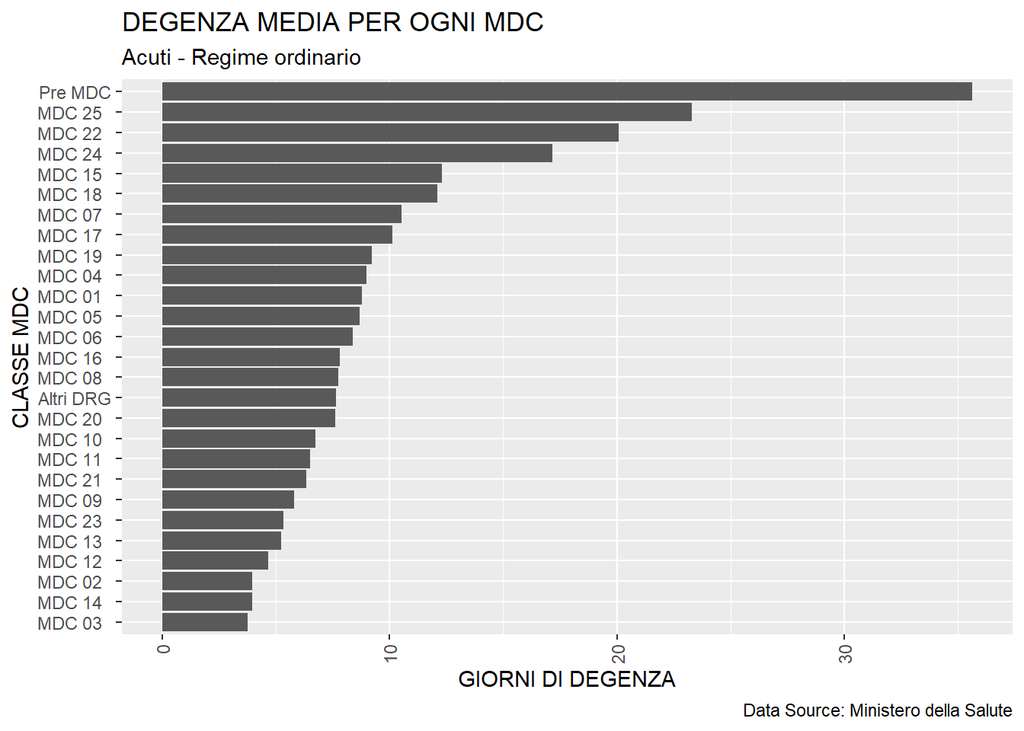

#### 2018

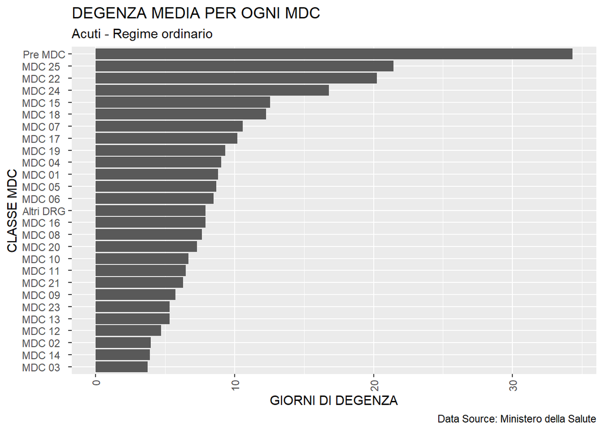

#### 2017

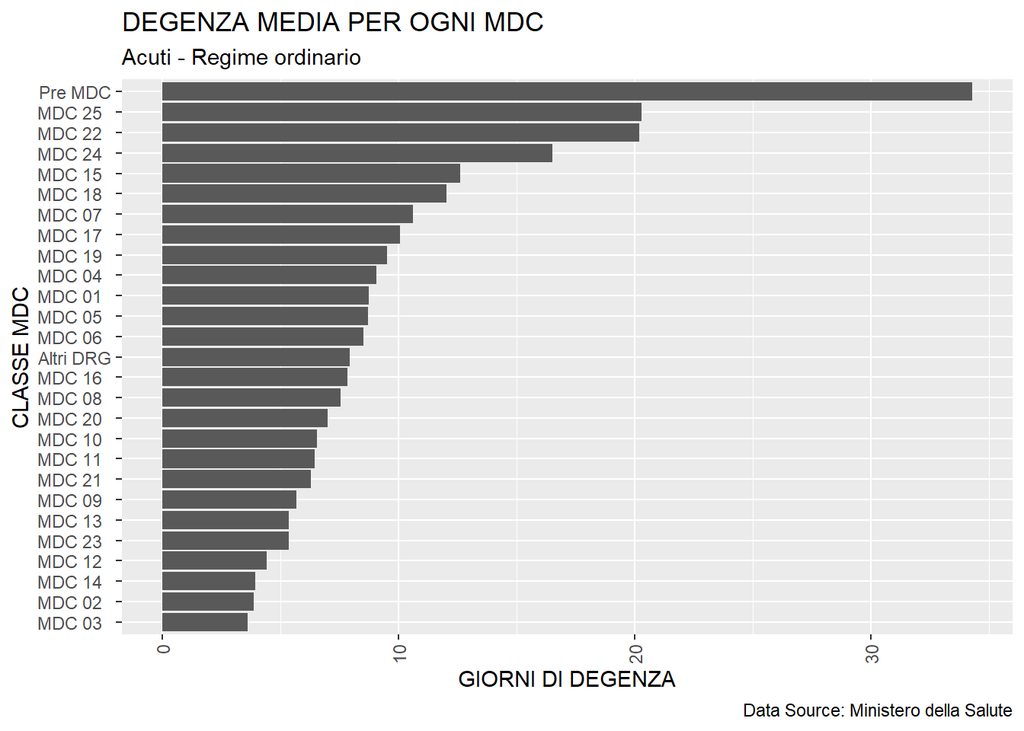

#### 2016

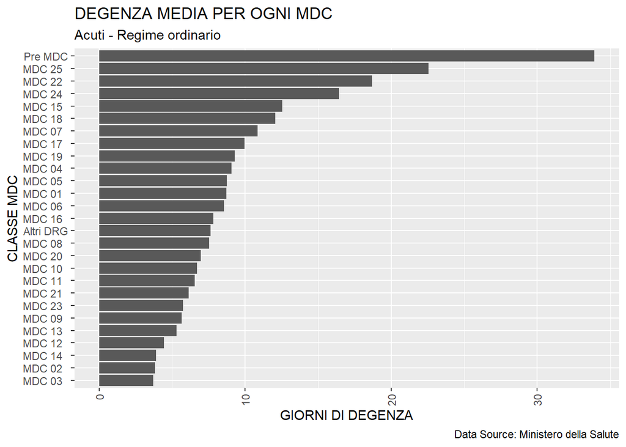

Table 1.1.6 provides a summary of Max, Min and Mean values for *“Giorni di Degenza”* for each MDC.

|  | CLASSE_MDC | ANNO | MAX_DEGENZA | MIN_DEGENZA | MEAN_DEGENZA |
| --- | --- | --- | --- | --- | --- |
| 1 | Altri DRG | 2016 | 222 | 1 | 7.631 |
| 2 | Altri DRG | 2017 | 315 | 1 | 7.933 |
| 3 | Altri DRG | 2018 | 255 | 1 | 7.919 |
| 4 | Altri DRG | 2019 | 217 | 1 | 7.664 |
| 5 | MDC 01 | 2016 | 365 | 1 | 8.706 |
| 6 | MDC 01 | 2017 | 340 | 1 | 8.76 |
| 7 | MDC 01 | 2018 | 348 | 1 | 8.83 |
| 8 | MDC 01 | 2019 | 362 | 1 | 8.773 |
| 9 | MDC 02 | 2016 | 119 | 1 | 3.839 |
| 10 | MDC 02 | 2017 | 144 | 1 | 3.888 |

[output cut: 98 more lines]

## 1.2 Acuti - Regime diurno.

### 1.2.1 DIMISSIONI

Table 1.2.1 provides a summary of the hospedalization discharges in *“Acuti - Regime diurno”* and the percentage variation year by year. As shown, there has been a decrease in the hospitalization discharges in this activity, in particular from 2016 to 2017, with a reduction of 6.71%.

|  | ANNO | DIMISSIONI | VARIAZIONE % |
| --- | --- | --- | --- |
| 1 | 2016 | 1951876 |  |
| 2 | 2017 | 1820907 | -6.71 |
| 3 | 2018 | 1767074 | -2.956 |
| 4 | 2019 | 1751585 | -0.877 |

This bar chart shows the hospital discharges by MDC for each year of the analysis.

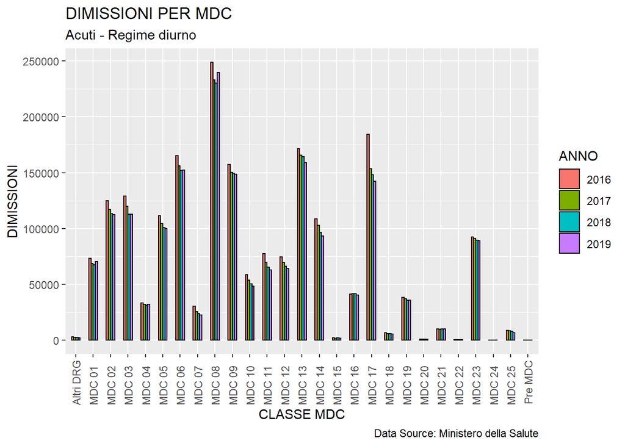

The following table provides a summary of the discharges for each MDC class and for each year.

|  | CLASSE_MDC | DIMISSIONI | ANNO |
| --- | --- | --- | --- |
| 1 | 01 - Malattie e disturbi del sistema nervoso | 73057 | 2016 |
| 2 | 02 - Malattie e disturbi dell'occhio | 124877 | 2016 |
| 3 | 03 - Malattie e disturbi dell'orecchio, del naso, della bocca e della gola | 129044 | 2016 |
| 4 | 04 - Malattie e disturbi dell'apparato respiratorio | 33087 | 2016 |
| 5 | 05 - Malattie e disturbi dell'apparato cardiocircolatorio | 111594 | 2016 |
| 6 | 06 - Malattie e disturbi dell'apparato digerente | 165293 | 2016 |
| 7 | 07 - Malattie e disturbi epatobiliari e del pancreas | 30525 | 2016 |
| 8 | 08 - Malattie e disturbi del sistema muscolo-scheletrico e del tessuto connettivo | 248788 | 2016 |
| 9 | 09 - Malattie e disturbi della pelle, del tessuto sottocutaneo e della mammella | 157326 | 2016 |
| 10 | 10 - Malattie e disturbi endocrini, nutrizionali e metabolici | 58595 | 2016 |

[output cut: 98 more lines]

The bar chart below shows the distribution of discharges in *Acuti - Regime diurno* per age category, for each year of analysis.

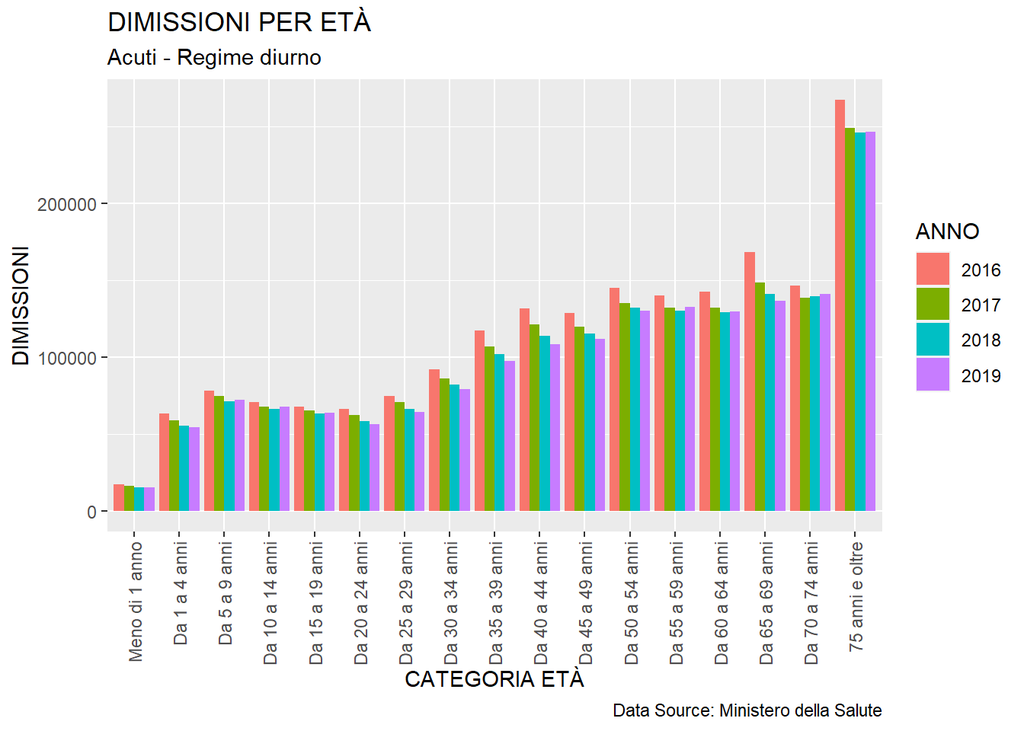

The following table provides a summary of the data presented about hospitalization discharges by age category.

|  | Categoria età | MASCHI | FEMMINE | ANNO | ATTIVITÀ |
| --- | --- | --- | --- | --- | --- |
| 1 | Meno di 1 anno | 9725 | 7454 | 2016 | Acuti - Regime diurno |
| 2 | Da 1 a 4 anni | 38943 | 24471 | 2016 | Acuti - Regime diurno |
| 3 | Da 5 a 9 anni | 45637 | 32555 | 2016 | Acuti - Regime diurno |
| 4 | Da 10 a 14 anni | 41455 | 29326 | 2016 | Acuti - Regime diurno |
| 5 | Da 15 a 19 anni | 36895 | 30772 | 2016 | Acuti - Regime diurno |
| 6 | Da 20 a 24 anni | 29873 | 36615 | 2016 | Acuti - Regime diurno |
| 7 | Da 25 a 29 anni | 27140 | 47380 | 2016 | Acuti - Regime diurno |
| 8 | Da 30 a 34 anni | 27246 | 64663 | 2016 | Acuti - Regime diurno |
| 9 | Da 35 a 39 anni | 31809 | 85460 | 2016 | Acuti - Regime diurno |
| 10 | Da 40 a 44 anni | 42229 | 89496 | 2016 | Acuti - Regime diurno |

[output cut: 58 more lines]

### 1.2.2 ACCESSI

The following graph shows the *Accessi* for each MDC and over the years of analysis.

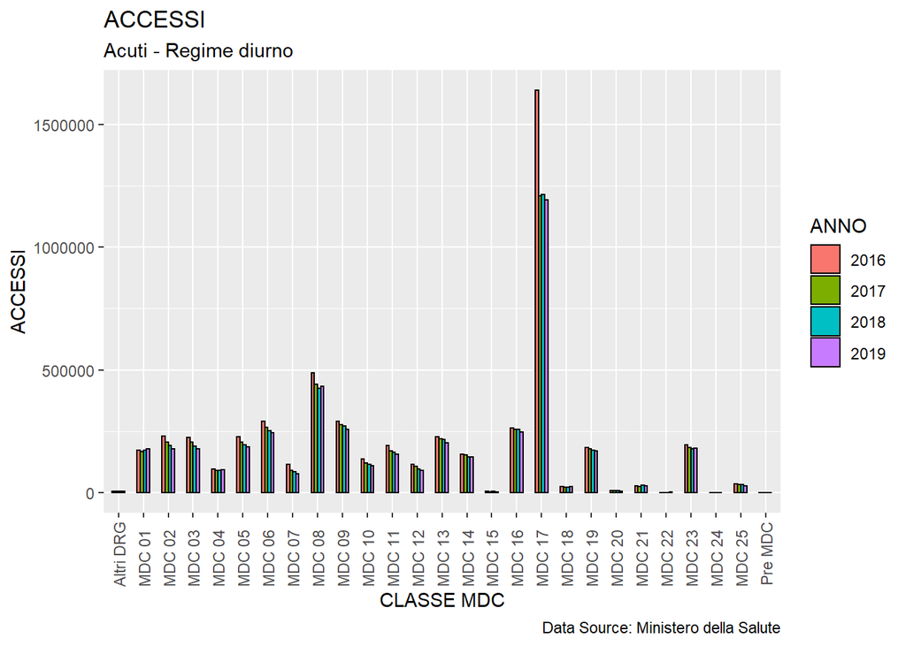

These bar charts shows the mean for the variable *Accessi* by each MDC and for the 4 years of analysis.

#### 2019

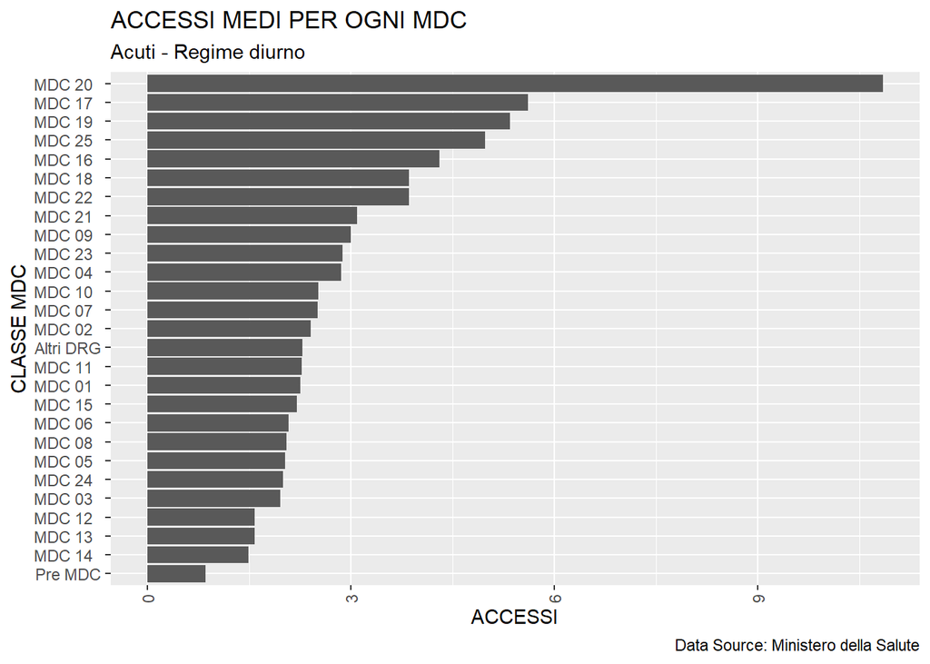

#### 2018

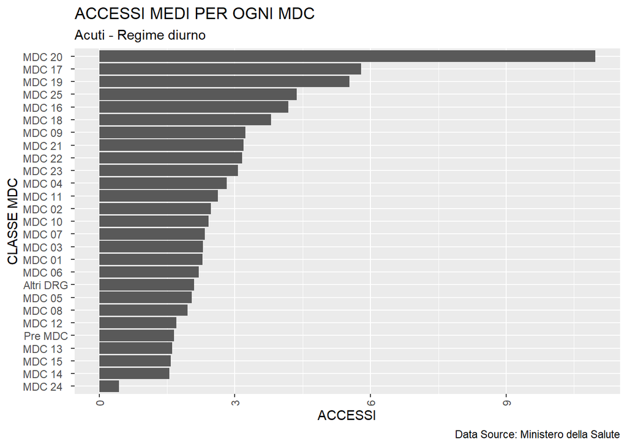

#### 2017

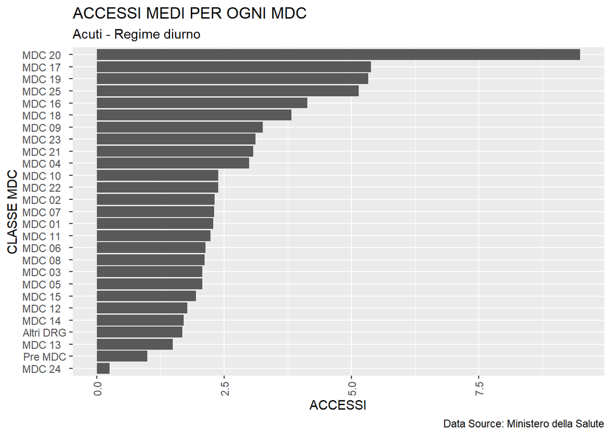

#### 2016

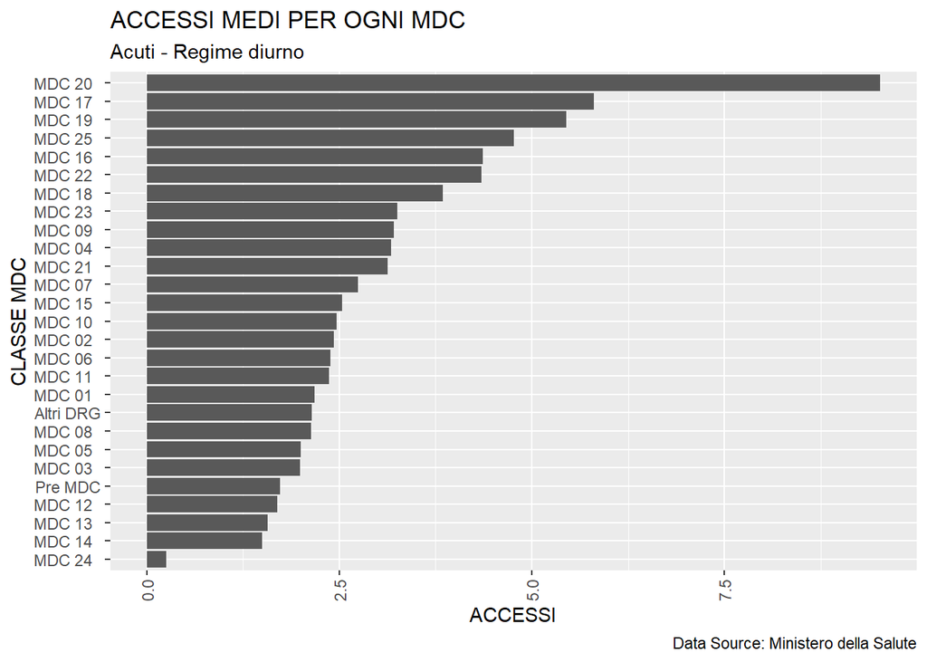

Table 1.2.4 provides a summary of Max, Min and Mean values for *“Accessi”* for each MDC.

|  | CLASSE_MDC | ANNO | MAX_accessi | MIN_accessi | MEAN_accessi |
| --- | --- | --- | --- | --- | --- |
| 1 | Altri DRG | 2016 | 77 | 1 | 2.143 |
| 2 | Altri DRG | 2017 | 50 | 1 | 1.681 |
| 3 | Altri DRG | 2018 | 72 | 1 | 2.101 |
| 4 | Altri DRG | 2019 | 117 | 1 | 2.291 |
| 5 | MDC 01 | 2016 | 141 | 0 | 2.177 |
| 6 | MDC 01 | 2017 | 101 | 0 | 2.289 |
| 7 | MDC 01 | 2018 | 138 | 0 | 2.278 |
| 8 | MDC 01 | 2019 | 133 | 0 | 2.252 |
| 9 | MDC 02 | 2016 | 78 | 1 | 2.427 |
| 10 | MDC 02 | 2017 | 98 | 1 | 2.317 |

[output cut: 98 more lines]

## 1.3 Riabilitazione - Regime ordinario.

### 1.3.1 DIMISSIONI

Table 1.3.1 provides a summary of the hospedalization discharges in *“Riabilitazione - Regime ordinario”* and the percentage variation from year to year. There is a reduction in the number of discharges from 2016 to 2018, then a slight increase in 2019. None of these is very significant.

|  | ANNO | DIMISSIONI | VARIAZIONE % |
| --- | --- | --- | --- |
| 1 | 2016 | 319113 |  |
| 2 | 2017 | 315956 | -0.989 |
| 3 | 2018 | 312423 | -1.118 |
| 4 | 2019 | 312678 | 0.082 |

This bar chart shows the hospital discharges by MDC for each year of the analysis.

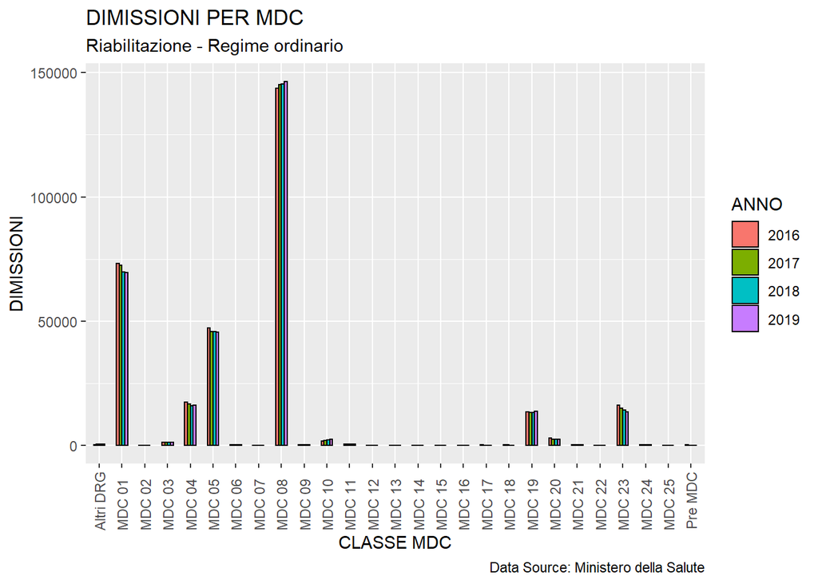

There are just a few MDC classes with a considerable number of discharges in *Riabilitazione - Regime ordinario*. These are: **MDC 08 - Malattie e disturbi del sistema muscolo-scheletrico e del tessuto connettivo**; **MDC 01 - Malattie e disturbi del sistema nervoso**; **MDC 05 - Malattie e disturbi dell’apparato cardiocircolatorio**.

Table 1.3.2 provides a summary of the discharges for each MDC class and for each year.

|  | CLASSE_MDC | DIMISSIONI | ANNO |
| --- | --- | --- | --- |
| 1 | 01 - Malattie e disturbi del sistema nervoso | 73237 | 2016 |
| 2 | 02 - Malattie e disturbi dell'occhio | 96 | 2016 |
| 3 | 03 - Malattie e disturbi dell'orecchio, del naso, della bocca e della gola | 1327 | 2016 |
| 4 | 04 - Malattie e disturbi dell'apparato respiratorio | 17261 | 2016 |
| 5 | 05 - Malattie e disturbi dell'apparato cardiocircolatorio | 47337 | 2016 |
| 6 | 06 - Malattie e disturbi dell'apparato digerente | 237 | 2016 |
| 7 | 07 - Malattie e disturbi epatobiliari e del pancreas | 88 | 2016 |
| 8 | 08 - Malattie e disturbi del sistema muscolo-scheletrico e del tessuto connettivo | 143710 | 2016 |
| 9 | 09 - Malattie e disturbi della pelle, del tessuto sottocutaneo e della mammella | 181 | 2016 |
| 10 | 10 - Malattie e disturbi endocrini, nutrizionali e metabolici | 1808 | 2016 |

[output cut: 98 more lines]

The bar chart below shows the distribution of discharges in *Riabilitazione - Regime ordinario* per age category, for each year of analysis.

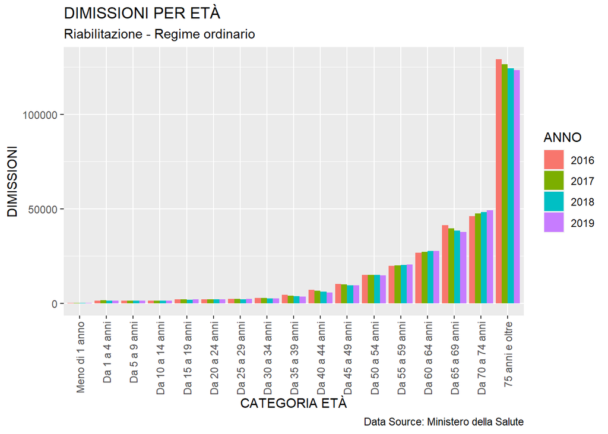

The following table provides a summary of the data presented about hospitalization discharges by age category.

|  | Categoria età | MASCHI | FEMMINE | ANNO | ATTIVITÀ |
| --- | --- | --- | --- | --- | --- |
| 1 | Meno di 1 anno | 108 | 59 | 2016 | Riabilitazione - Regime ordinario |
| 2 | Da 1 a 4 anni | 1012 | 496 | 2016 | Riabilitazione - Regime ordinario |
| 3 | Da 5 a 9 anni | 937 | 571 | 2016 | Riabilitazione - Regime ordinario |
| 4 | Da 10 a 14 anni | 821 | 631 | 2016 | Riabilitazione - Regime ordinario |
| 5 | Da 15 a 19 anni | 1091 | 1029 | 2016 | Riabilitazione - Regime ordinario |
| 6 | Da 20 a 24 anni | 1293 | 920 | 2016 | Riabilitazione - Regime ordinario |
| 7 | Da 25 a 29 anni | 1441 | 932 | 2016 | Riabilitazione - Regime ordinario |
| 8 | Da 30 a 34 anni | 1674 | 1123 | 2016 | Riabilitazione - Regime ordinario |
| 9 | Da 35 a 39 anni | 2699 | 1689 | 2016 | Riabilitazione - Regime ordinario |
| 10 | Da 40 a 44 anni | 4351 | 2687 | 2016 | Riabilitazione - Regime ordinario |

[output cut: 58 more lines]

### 1.3.2 GIORNATE DI DEGENZA

The following graph shows the *Giorni di Degenza* for each MDC and over the years of analysis.

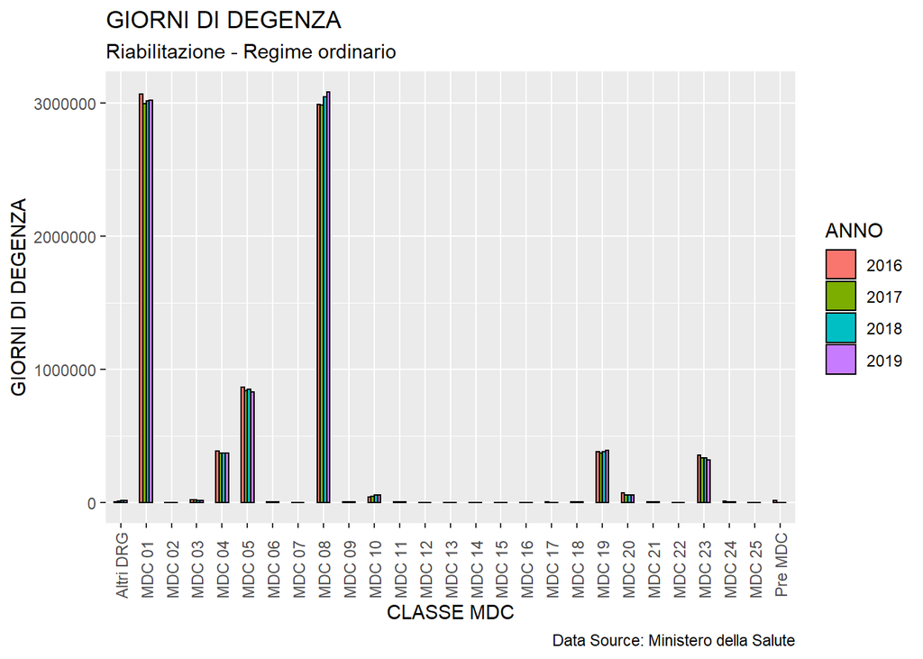

Table 1.3.4 provides a summary for *Giorni di Degenza* by MDC for each year.

|  | CLASSE_MDC | GIORNATE DI DEGENZA | ANNO |
| --- | --- | --- | --- |
| 1 | 01 - Malattie e disturbi del sistema nervoso | 3067991 | 2016 |
| 2 | 02 - Malattie e disturbi dell'occhio | 942 | 2016 |
| 3 | 03 - Malattie e disturbi dell'orecchio, del naso, della bocca e della gola | 17889 | 2016 |
| 4 | 04 - Malattie e disturbi dell'apparato respiratorio | 387005 | 2016 |
| 5 | 05 - Malattie e disturbi dell'apparato cardiocircolatorio | 865627 | 2016 |
| 6 | 06 - Malattie e disturbi dell'apparato digerente | 4892 | 2016 |
| 7 | 07 - Malattie e disturbi epatobiliari e del pancreas | 1619 | 2016 |
| 8 | 08 - Malattie e disturbi del sistema muscolo-scheletrico e del tessuto connettivo | 2990077 | 2016 |
| 9 | 09 - Malattie e disturbi della pelle, del tessuto sottocutaneo e della mammella | 5734 | 2016 |
| 10 | 10 - Malattie e disturbi endocrini, nutrizionali e metabolici | 43174 | 2016 |

[output cut: 98 more lines]

The following graph shows the Mean value for *Giorni di Degenza* for each MDC.

#### 2019

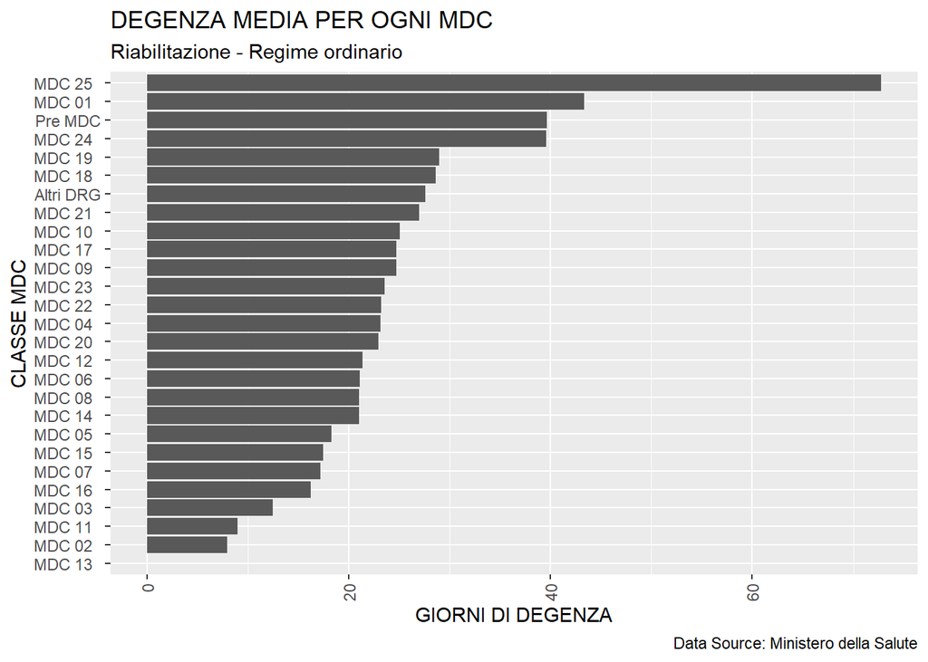

#### 2018

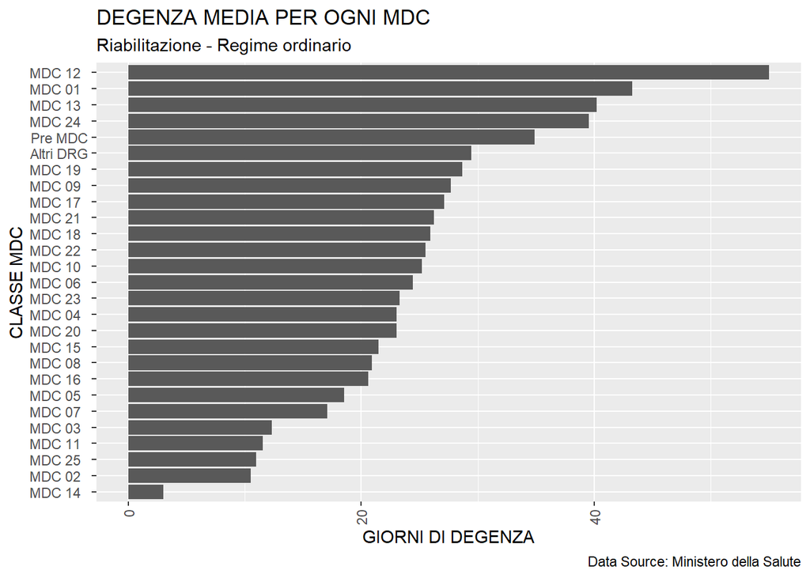

#### 2017

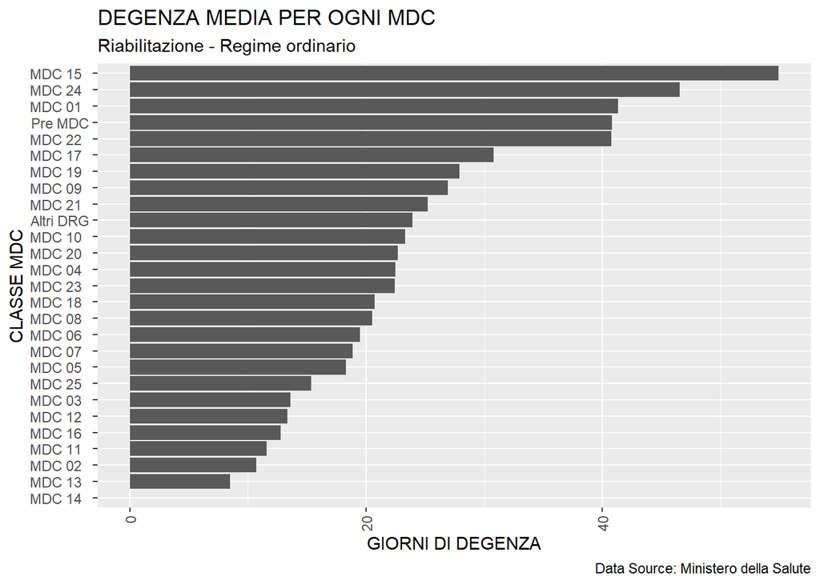

#### 2016

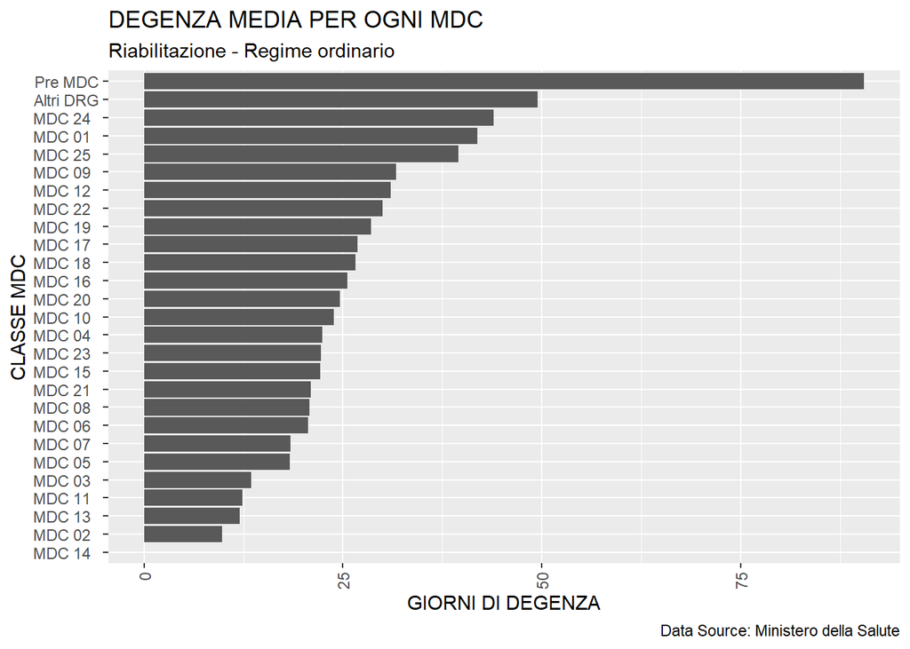

Table 1.3.5 provides a summary for the mean value for *“Giorni di Degenza”*, for each MDC.

|  | CLASSE_MDC | DEGENZA MEDIA (giorni) | ANNO |
| --- | --- | --- | --- |
| 1 | 01 - Malattie e disturbi del sistema nervoso | 41.891 | 2016 |
| 2 | 02 - Malattie e disturbi dell'occhio | 9.812 | 2016 |
| 3 | 03 - Malattie e disturbi dell'orecchio, del naso, della bocca e della gola | 13.481 | 2016 |
| 4 | 04 - Malattie e disturbi dell'apparato respiratorio | 22.421 | 2016 |
| 5 | 05 - Malattie e disturbi dell'apparato cardiocircolatorio | 18.286 | 2016 |
| 6 | 06 - Malattie e disturbi dell'apparato digerente | 20.641 | 2016 |
| 7 | 07 - Malattie e disturbi epatobiliari e del pancreas | 18.398 | 2016 |
| 8 | 08 - Malattie e disturbi del sistema muscolo-scheletrico e del tessuto connettivo | 20.806 | 2016 |
| 9 | 09 - Malattie e disturbi della pelle, del tessuto sottocutaneo e della mammella | 31.68 | 2016 |
| 10 | 10 - Malattie e disturbi endocrini, nutrizionali e metabolici | 23.879 | 2016 |

[output cut: 98 more lines]

## 1.4 Riabilitazione - Regime diurno.

### 1.4.1 DIMISSIONI

Table 1.4.1 provides a summary of the hospedalization discharges in *“Riabilitazione - Regime diurno”* and the percentage variation from year to year. As shown, there has been an important decrease in hospitalization discharges in between 2017 and 2018 (-6.745%).

|  | ANNO | DIMISSIONI | VARIAZIONE % |
| --- | --- | --- | --- |
| 1 | 2016 | 31955 |  |
| 2 | 2017 | 30450 | -4.71 |
| 3 | 2018 | 28396 | -6.745 |
| 4 | 2019 | 28527 | 0.461 |

This bar chart shows the hospital discharges by MDC for each year of the analysis.

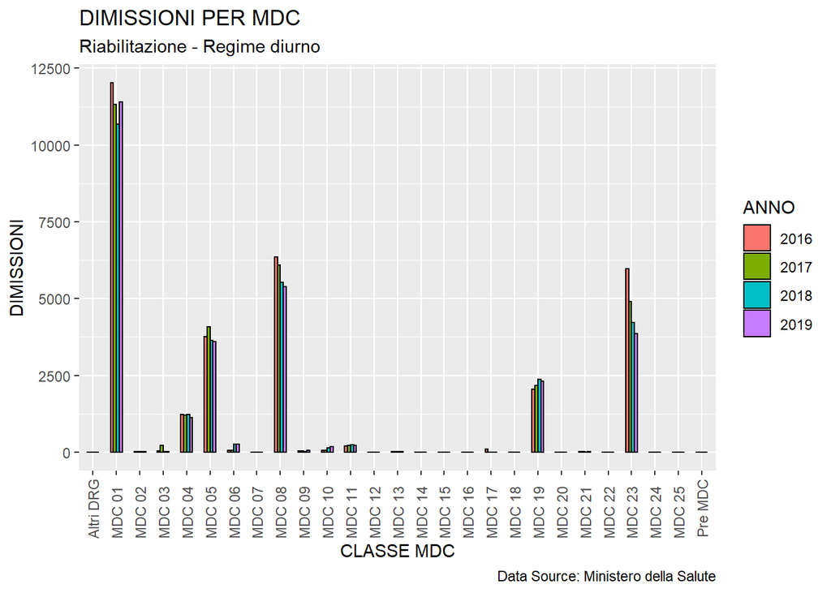

In the case of activity *Riabilitazione - Regime diurno*, there are a few MDC with a considerable level of discharges: **MDC 01 - Malattie e disturbi del sistema nervoso**; **MDC 08 - Malattie e disturbi del sistema muscolo-scheletrico e del tessuto connettivo**; **MDC 23 - Fattori che influenzano lo stato di salute ed il ricorso ai servizi sanitari**.

The following table provides a summary of the discharges for by MDC class and for each year of the analysis.

|  | CLASSE_MDC | DIMISSIONI | ANNO |
| --- | --- | --- | --- |
| 1 | 01 - Malattie e disturbi del sistema nervoso | 12020 | 2016 |
| 2 | 02 - Malattie e disturbi dell'occhio | 24 | 2016 |
| 3 | 03 - Malattie e disturbi dell'orecchio, del naso, della bocca e della gola | 31 | 2016 |
| 4 | 04 - Malattie e disturbi dell'apparato respiratorio | 1221 | 2016 |
| 5 | 05 - Malattie e disturbi dell'apparato cardiocircolatorio | 3765 | 2016 |
| 6 | 06 - Malattie e disturbi dell'apparato digerente | 61 | 2016 |
| 7 | 07 - Malattie e disturbi epatobiliari e del pancreas | 2 | 2016 |
| 8 | 08 - Malattie e disturbi del sistema muscolo-scheletrico e del tessuto connettivo | 6348 | 2016 |
| 9 | 09 - Malattie e disturbi della pelle, del tessuto sottocutaneo e della mammella | 35 | 2016 |
| 10 | 10 - Malattie e disturbi endocrini, nutrizionali e metabolici | 52 | 2016 |

[output cut: 98 more lines]

The bar chart below shows the distribution of discharges in *Riabilitazione - Regime diurno* per age category, for each year of analysis.

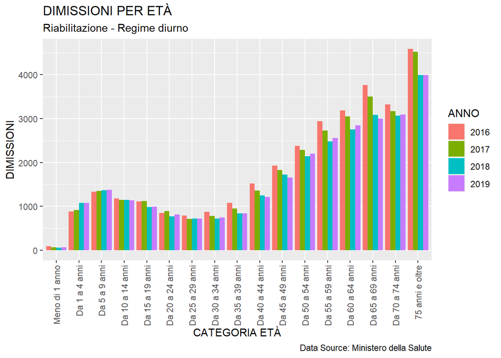

The following table provides a summary of the data presented about hospitalization discharges by age category.

|  | Categoria età | MASCHI | FEMMINE | ANNO | ATTIVITÀ |
| --- | --- | --- | --- | --- | --- |
| 1 | Meno di 1 anno | 53 | 40 | 2016 | Riabilitazione - Regime diurno |
| 2 | Da 1 a 4 anni | 552 | 327 | 2016 | Riabilitazione - Regime diurno |
| 3 | Da 5 a 9 anni | 912 | 418 | 2016 | Riabilitazione - Regime diurno |
| 4 | Da 10 a 14 anni | 782 | 402 | 2016 | Riabilitazione - Regime diurno |
| 5 | Da 15 a 19 anni | 646 | 468 | 2016 | Riabilitazione - Regime diurno |
| 6 | Da 20 a 24 anni | 520 | 327 | 2016 | Riabilitazione - Regime diurno |
| 7 | Da 25 a 29 anni | 495 | 296 | 2016 | Riabilitazione - Regime diurno |
| 8 | Da 30 a 34 anni | 545 | 333 | 2016 | Riabilitazione - Regime diurno |
| 9 | Da 35 a 39 anni | 667 | 412 | 2016 | Riabilitazione - Regime diurno |
| 10 | Da 40 a 44 anni | 917 | 602 | 2016 | Riabilitazione - Regime diurno |

[output cut: 58 more lines]

### 1.4.2 ACCESSI

The following graph shows the *Accessi* for each MDC and over the years of analysis.

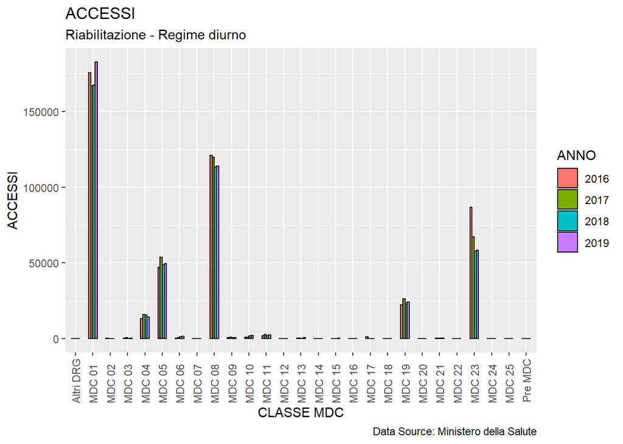

Table 1.4.4 provides a summary for *Accessi* by MDC for each year.

|  | CLASSE_MDC | ACCESSI | ANNO |
| --- | --- | --- | --- |
| 1 | 01 - Malattie e disturbi del sistema nervoso | 175667 | 2016 |
| 2 | 02 - Malattie e disturbi dell'occhio | 160 | 2016 |
| 3 | 03 - Malattie e disturbi dell'orecchio, del naso, della bocca e della gola | 177 | 2016 |
| 4 | 04 - Malattie e disturbi dell'apparato respiratorio | 13246 | 2016 |
| 5 | 05 - Malattie e disturbi dell'apparato cardiocircolatorio | 47034 | 2016 |
| 6 | 06 - Malattie e disturbi dell'apparato digerente | 400 | 2016 |
| 7 | 07 - Malattie e disturbi epatobiliari e del pancreas | 28 | 2016 |
| 8 | 08 - Malattie e disturbi del sistema muscolo-scheletrico e del tessuto connettivo | 120924 | 2016 |
| 9 | 09 - Malattie e disturbi della pelle, del tessuto sottocutaneo e della mammella | 572 | 2016 |
| 10 | 10 - Malattie e disturbi endocrini, nutrizionali e metabolici | 755 | 2016 |

[output cut: 98 more lines]

The following graph shows the Mean value for *Accessi* for each MDC.

#### 2019

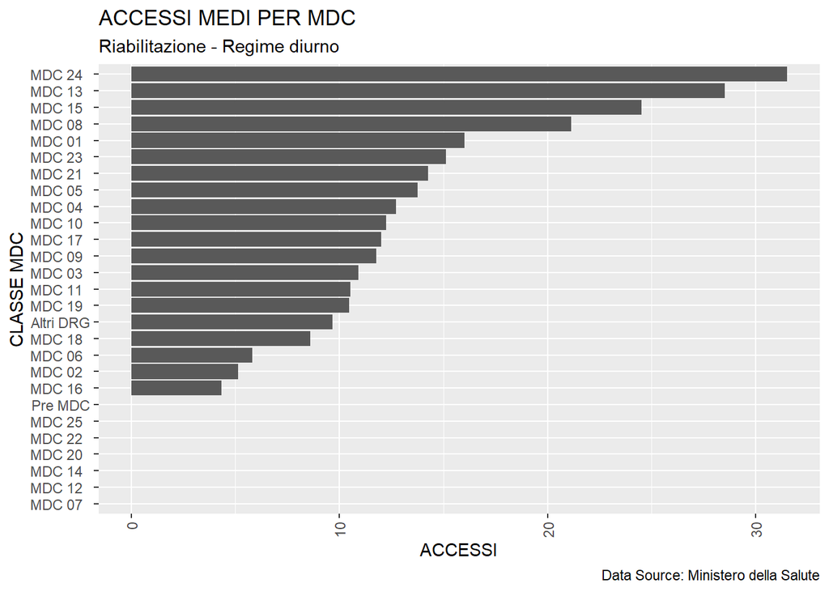

#### 2018

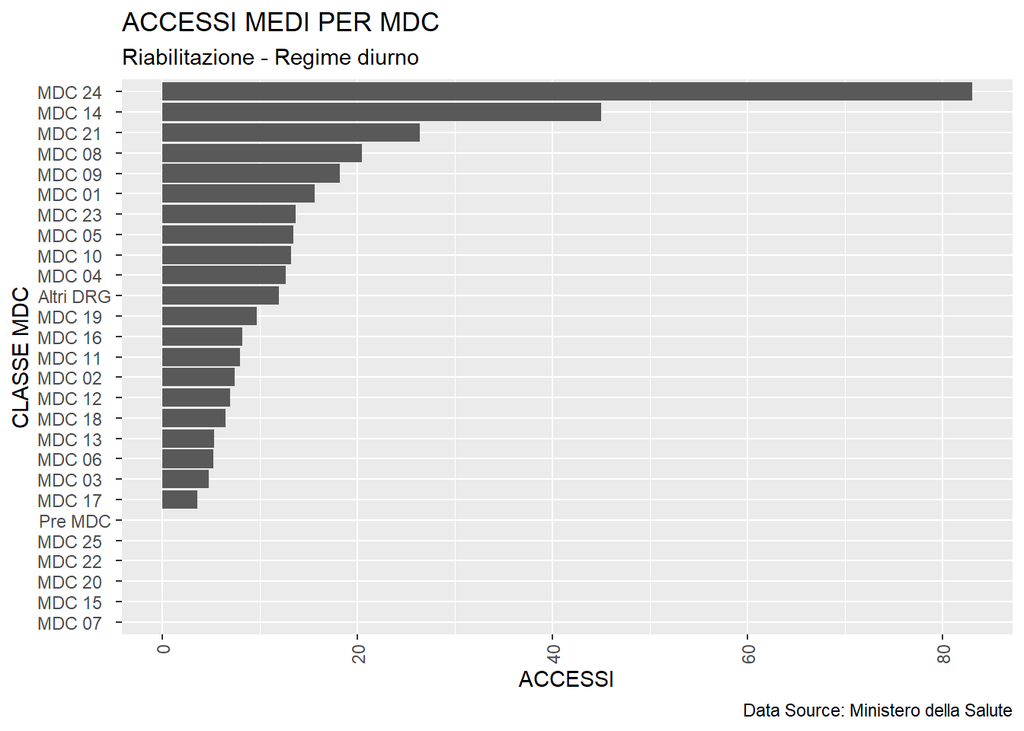

#### 2017

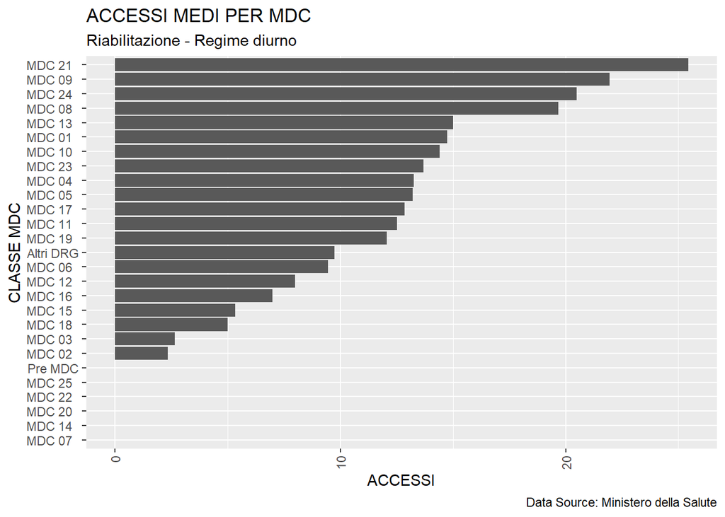

#### 2016

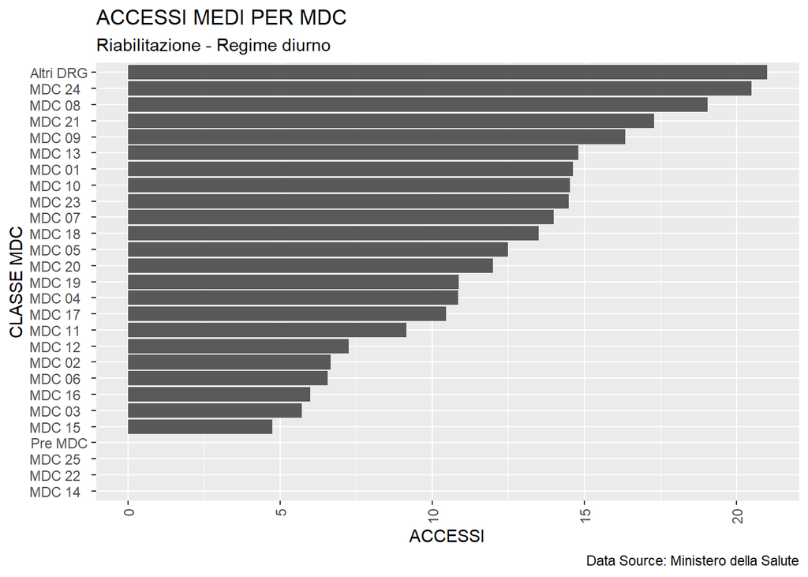

Table 1.4.5 provides a summary for the mean value for *Accessi* for each MDC.

|  | CLASSE_MDC | NUMERO MEDIO DI ACCESSI | ANNO |
| --- | --- | --- | --- |
| 1 | 01 - Malattie e disturbi del sistema nervoso | 14.615 | 2016 |
| 2 | 02 - Malattie e disturbi dell'occhio | 6.667 | 2016 |
| 3 | 03 - Malattie e disturbi dell'orecchio, del naso, della bocca e della gola | 5.71 | 2016 |
| 4 | 04 - Malattie e disturbi dell'apparato respiratorio | 10.848 | 2016 |
| 5 | 05 - Malattie e disturbi dell'apparato cardiocircolatorio | 12.492 | 2016 |
| 6 | 06 - Malattie e disturbi dell'apparato digerente | 6.557 | 2016 |
| 7 | 07 - Malattie e disturbi epatobiliari e del pancreas | 14 | 2016 |
| 8 | 08 - Malattie e disturbi del sistema muscolo-scheletrico e del tessuto connettivo | 19.049 | 2016 |
| 9 | 09 - Malattie e disturbi della pelle, del tessuto sottocutaneo e della mammella | 16.343 | 2016 |
| 10 | 10 - Malattie e disturbi endocrini, nutrizionali e metabolici | 14.519 | 2016 |

[output cut: 98 more lines]

## 1.5 Lungodegenza.

### 1.5.1 DIMISSIONI

Table 1.5.1 provides a summary of the hospedalization discharges in *Lungodegenza* and the percentage variation year by year.

|  | ANNO | DIMISSIONI | VARIAZIONE % |
| --- | --- | --- | --- |
| 1 | 2016 | 319113 |  |
| 2 | 2017 | 315956 | -0.989 |
| 3 | 2018 | 312423 | -1.118 |
| 4 | 2019 | 312678 | 0.082 |

This bar chart shows the hospital discharges by MDC for each year of the analysis.

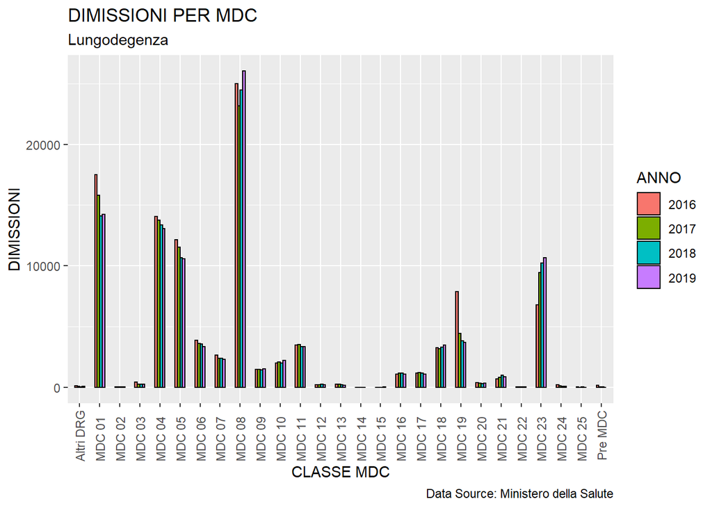

As shown from the bar chart, over the 4 years of analysis, the MDC classes with the greatest number of discharges for the activity *Lungodegenza* are: **MDC 08 - Malattie e disturbi del sistema muscolo-scheletrico e del tessuto connettivo**; **MDC 01 - Malattie e disturbi del sistema nervoso**; **MDC 04 - Malattie e disturbi dell’apparato respiratorio**.

The following table provides a summary of the discharges for each MDC class and for each year.

|  | CLASSE_MDC | DIMISSIONI | ANNO |
| --- | --- | --- | --- |
| 1 | 01 - Malattie e disturbi del sistema nervoso | 17485 | 2016 |
| 2 | 02 - Malattie e disturbi dell'occhio | 32 | 2016 |
| 3 | 03 - Malattie e disturbi dell'orecchio, del naso, della bocca e della gola | 443 | 2016 |
| 4 | 04 - Malattie e disturbi dell'apparato respiratorio | 14070 | 2016 |
| 5 | 05 - Malattie e disturbi dell'apparato cardiocircolatorio | 12153 | 2016 |
| 6 | 06 - Malattie e disturbi dell'apparato digerente | 3885 | 2016 |
| 7 | 07 - Malattie e disturbi epatobiliari e del pancreas | 2641 | 2016 |
| 8 | 08 - Malattie e disturbi del sistema muscolo-scheletrico e del tessuto connettivo | 24975 | 2016 |
| 9 | 09 - Malattie e disturbi della pelle, del tessuto sottocutaneo e della mammella | 1459 | 2016 |
| 10 | 10 - Malattie e disturbi endocrini, nutrizionali e metabolici | 2009 | 2016 |

[output cut: 98 more lines]

The bar chart below shows the distribution of discharges in *Lungodegenza* per age category, for each year of analysis.

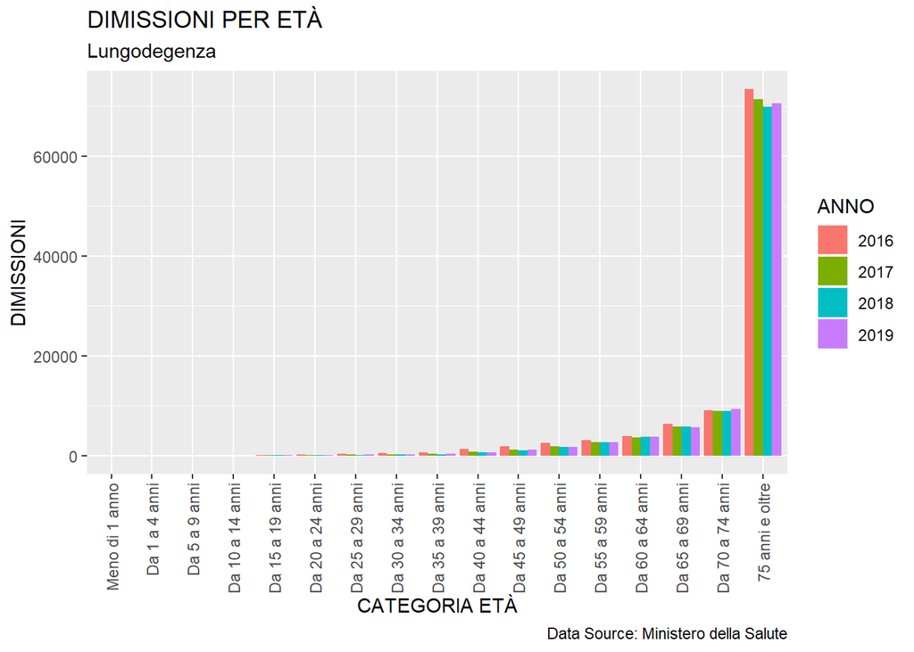

The following table provides a summary of the data presented about hospitalization discharges by age category.

|  | Categoria età | MASCHI | FEMMINE | ANNO | ATTIVITÀ |
| --- | --- | --- | --- | --- | --- |
| 1 | Meno di 1 anno | 3 | 2 | 2016 | Lungodegenza |
| 2 | Da 1 a 4 anni | 0 | 0 | 2016 | Lungodegenza |
| 3 | Da 5 a 9 anni | 0 | 0 | 2016 | Lungodegenza |
| 4 | Da 10 a 14 anni | 2 | 3 | 2016 | Lungodegenza |
| 5 | Da 15 a 19 anni | 74 | 58 | 2016 | Lungodegenza |
| 6 | Da 20 a 24 anni | 181 | 129 | 2016 | Lungodegenza |
| 7 | Da 25 a 29 anni | 235 | 153 | 2016 | Lungodegenza |
| 8 | Da 30 a 34 anni | 333 | 172 | 2016 | Lungodegenza |
| 9 | Da 35 a 39 anni | 403 | 295 | 2016 | Lungodegenza |
| 10 | Da 40 a 44 anni | 772 | 506 | 2016 | Lungodegenza |

[output cut: 58 more lines]